# Parctical10

AnaBasiri

8 December 2018

# Surface Interpolation in R

In this practical we use London air pollution data. you may go to this website and download 2013 emission data: https://data.london.gov.uk/dataset/london-atmospheric-emissions-inventory-2013

```r
#setwd("C:/AnaBasiri/Teaching/GISModule2018AnaBasiri/Week10/Practical8")
#install.packages("gstat")
library(ggplot2)
library(gstat)
library(sp)
library(maptools)
#install.packages("sf")
library(sf)
```

Your Airpollution data have lat and lon for the point where the pollutants are measured. If you wish to download data from teh link I shared, please make sure your columns names are renamed to x and y or simply use the 2008LondonAirData file I put on Moodle. This file has got a small portion of all air data quality data. Let’s read the csv file and then convert it to a spatial points data frame using the coordinates function in the sp package.

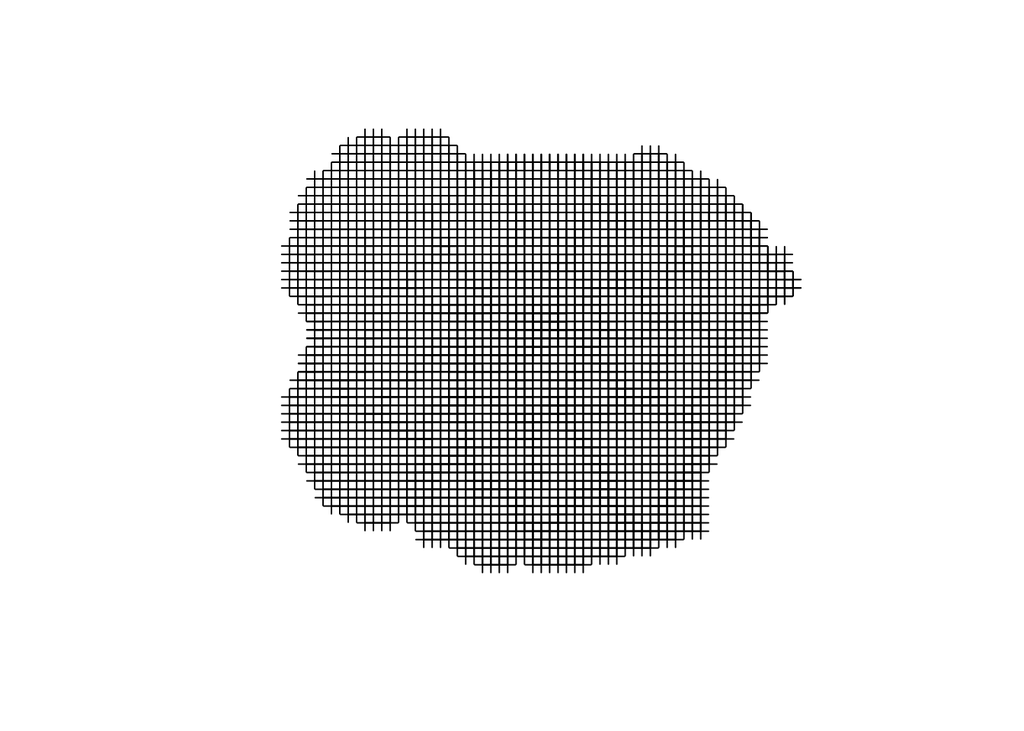

```r
#read in some data that already has x and y coordinates attached to it
AirData <- read.csv("/Volumes/ucfnnap/CASA_GIS and Sc/wk10/Practical10-2018-20181212/Practical10-2018/RPart/2008LondonAirData.csv")



#In our case the coordinates columns are already called x and y, so we will use these
#If your x and y has got any thing but float/numeric data type, edit!

#convert this basic data frame into a spatial points data frame
coordinates(AirData)= ~x+y

plot(AirData)
```

We will now create a grid onto which we will interpolate - this can be done in 2 ways. The first will set the grid using the range of the points data. This is OK, but our interpolation grid will not cover the full extent of our area.

```r
## 1. Create a grid from the values in your points dataframe
## first get the range in data
x.range <- as.integer(range(AirData@coords[,1]))
y.range <- as.integer(range(AirData@coords[,2]))
```

The second method lets you set your own grid extent using the locator() function. I put this part in comment and so if you wish to try please make sure you run them! After entering (4) into the function, you should click the four corners of a bounding box larger than the extent of London. I put the second way in commen These four points will be printed to the console and you can then enter them into your x.range and y.range variables:

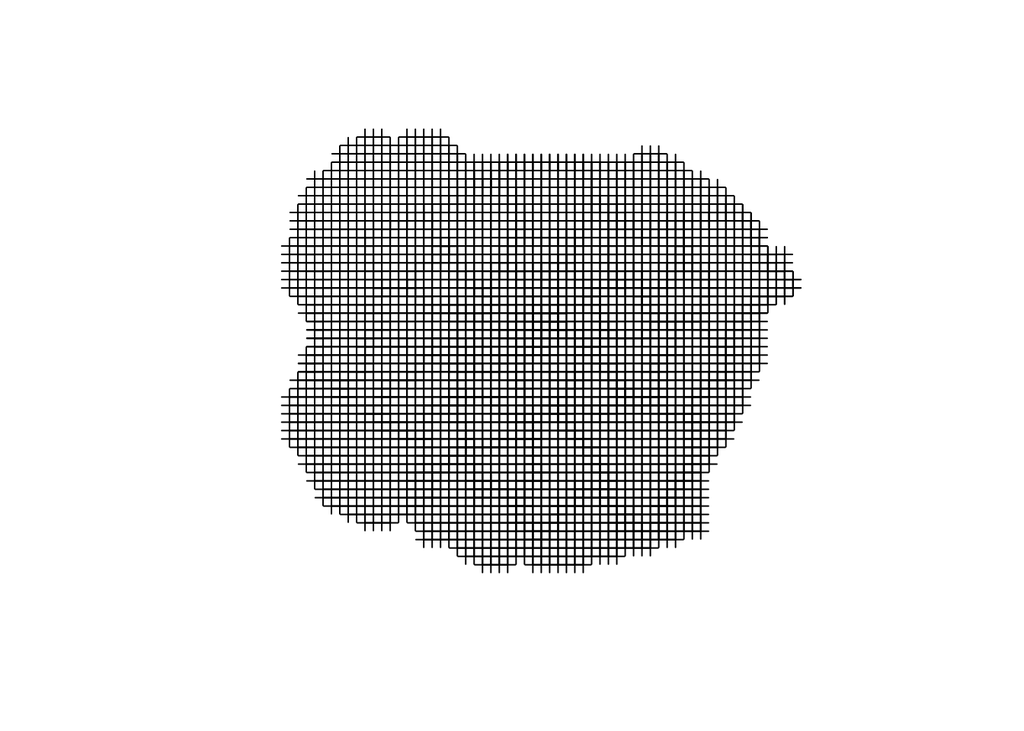

```r
##2. Create a grid with a slightly larger extent
plot(AirData)
#use the locator to click 4 points beyond the extent of the plot
#and use those to set your x and y extents
locator(4)
```

```r
x.range <- as.integer(c(497509.5,563596.8))
y.range <- as.integer(c(148358.5,207326.7))
```

We will now create a grid with the extent set to our x and y ranges. It is at this point that we set the resolution of the grid. Higher resolution (smaller grid cells) will create a smoother looking grid, but will involve more computation. As British National Grid is in metres, the range is set in metres.

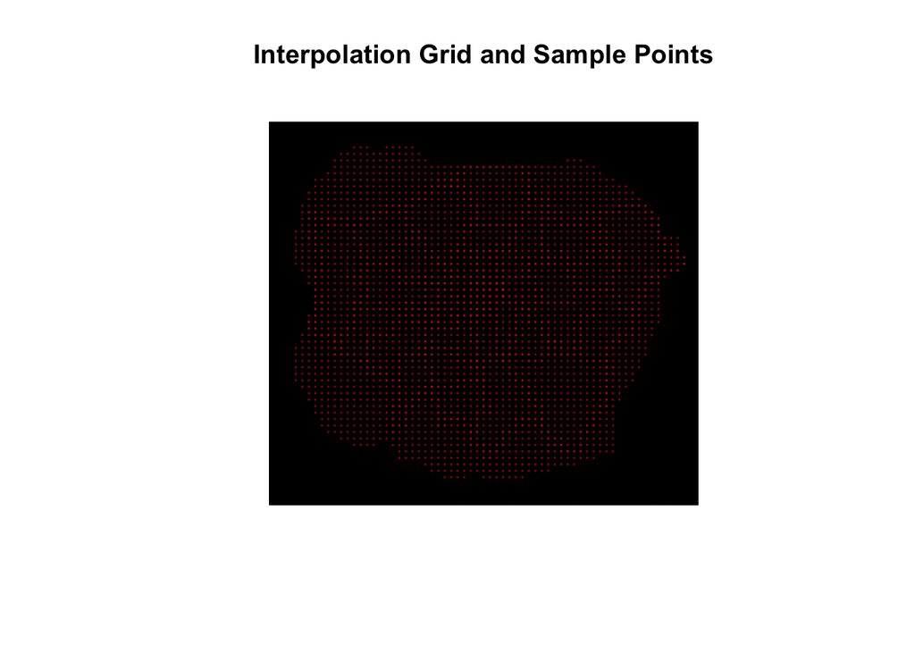

```r
## now expand your range to a grid with spacing that you'd like to use in your interpolation
#here we will use 150m grid cells:
grd <- expand.grid(x=seq(from=x.range[1], to=x.range[2], by=150), y=seq(from=y.range[1], to=y.range[2], by=150))

## convert grid to SpatialPixel class
coordinates(grd) <- ~ x+y
gridded(grd) <- TRUE

## test it out - this is a good way of checking that your sample points are all well within your grid. If they are not, try some different values in you r x and y ranges:
plot(grd, cex=0.5)

points(AirData, pch=1, col='red', cex=0.05)
title("Interpolation Grid and Sample Points")
```

## Inverse Distance Weighting

Now we have set up our points and a grid to interpolate onto, we are ready carry out some interpolation. The first method we will try is inverse distance weighting (IDW) as this will not require any special modelling of spatial relationships.

To generate a surface using inverse distance weighting, use the IDW function in gstat. Check the help file for IDW - `?idw` - for information about what this formula is doing.

The surface being generated here for one variable (Total) across the whole London area. Feel free to experiment with smoothing alternative variables.

```r
idw<-idw(formula=Total ~ 1, locations=AirData, newdata=grd)
```

```
## [inverse distance weighted interpolation]
```

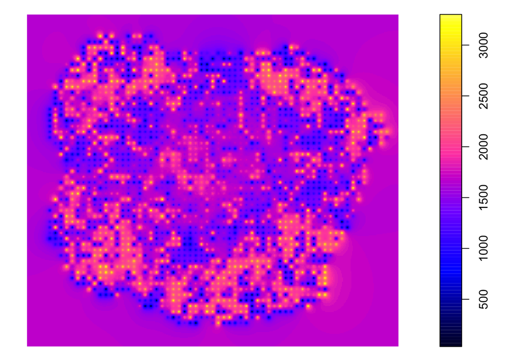

```r
idw.output=as.data.frame(idw)
names(idw.output)[1:3]<-c("x","y","Total")
plot (idw)
```

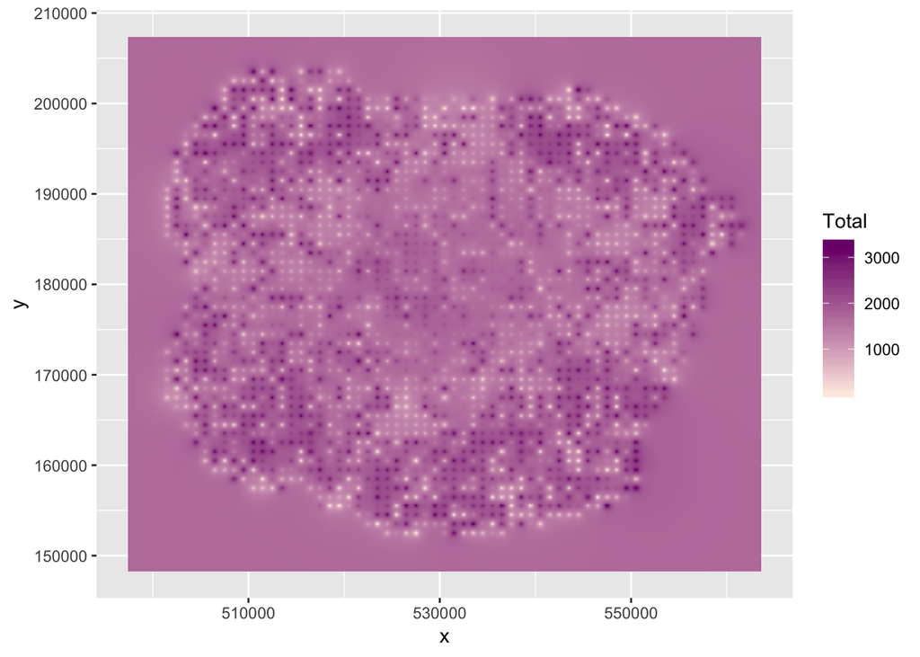

```r
plot<-ggplot(data=idw.output,aes(x=x,y=y))
layer1<-c(geom_tile(data=idw.output,aes(fill=Total)))#then create a tile layer and fill with predicted values
plot+layer1+scale_fill_gradient(low="#FEEBE2", high="#7A0177")
```

You might want to experiment with other variables or a few of the parameters in IDW or different grid resolutions.

## Kriging

As you heard in the lecture, Kriging is a little more involved than IDW as it requires the construction of a semivariogram model to describe the spatial autocorrelation pattern for your particular variable.

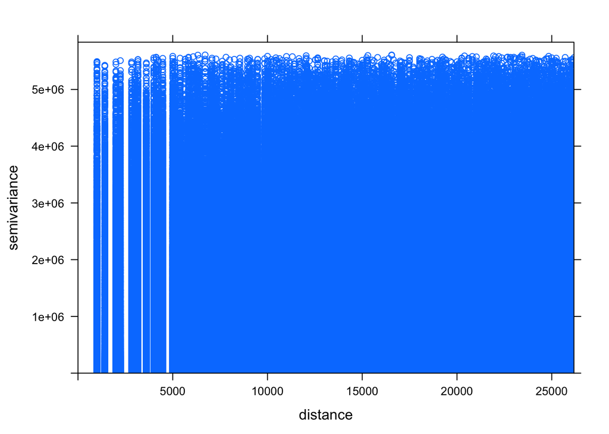

```r
AirData1 <- AirData[-zerodist(AirData)[,1],]
variogcloud<-variogram(Total~1, locations=AirData1, data=AirData1, cloud=TRUE)
plot(variogcloud)
```

The values in the cloud can be binned into lags with and plotted with a very similar function

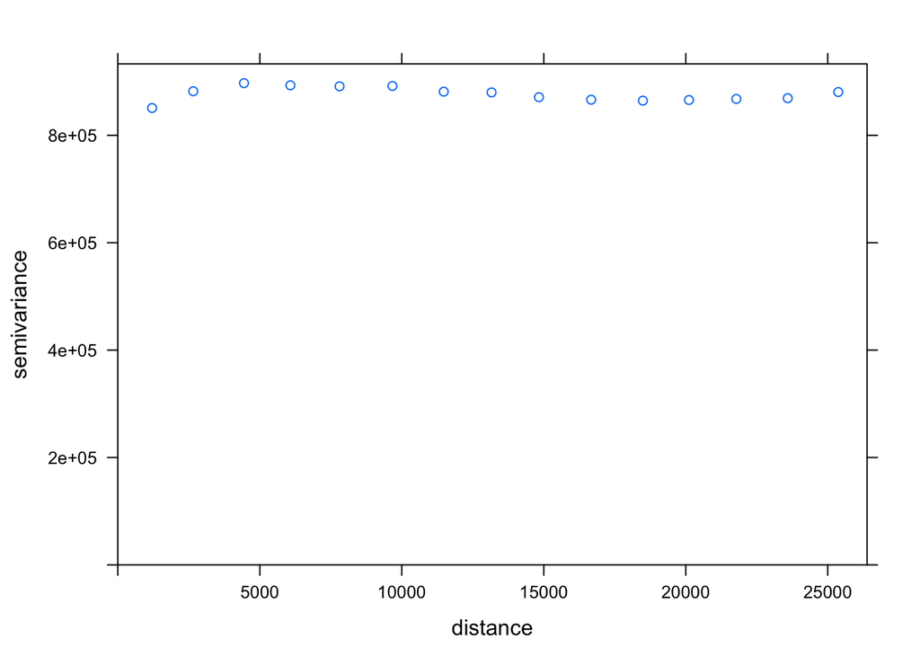

```r
semivariog<-variogram(Total~1, locations = AirData1, data=AirData1)
plot(semivariog)
```

```r
semivariog
```

```
##        np      dist    gamma dir.hor dir.ver   id
## 1    9565  1205.829 850922.2       0       0 var1
## 2   32264  2655.449 882072.7       0       0 var1
## 3   57189  4442.194 897131.3       0       0 var1
## 4   58934  6075.708 893159.8       0       0 var1
## 5   96339  7806.519 891226.3       0       0 var1
## 6  102821  9670.242 891850.4       0       0 var1
## 7  118862 11476.435 881326.1       0       0 var1
## 8  109283 13160.438 879897.2       0       0 var1
## 9  135944 14828.199 870954.0       0       0 var1
## 10 149028 16667.836 866323.8       0       0 var1
## 11 145124 18489.141 864604.0       0       0 var1
## 12 128211 20112.489 865753.8       0       0 var1
## 13 155408 21779.883 867747.5       0       0 var1
## 14 155767 23589.835 869122.9       0       0 var1
## 15 148373 25368.736 880585.7       0       0 var1
```

From the empirical semivariogram plot and the information contained in the semivariog gstat object, we can estimate the sill, range and nugget to use in our model semivariogram.